# IE582 Fall

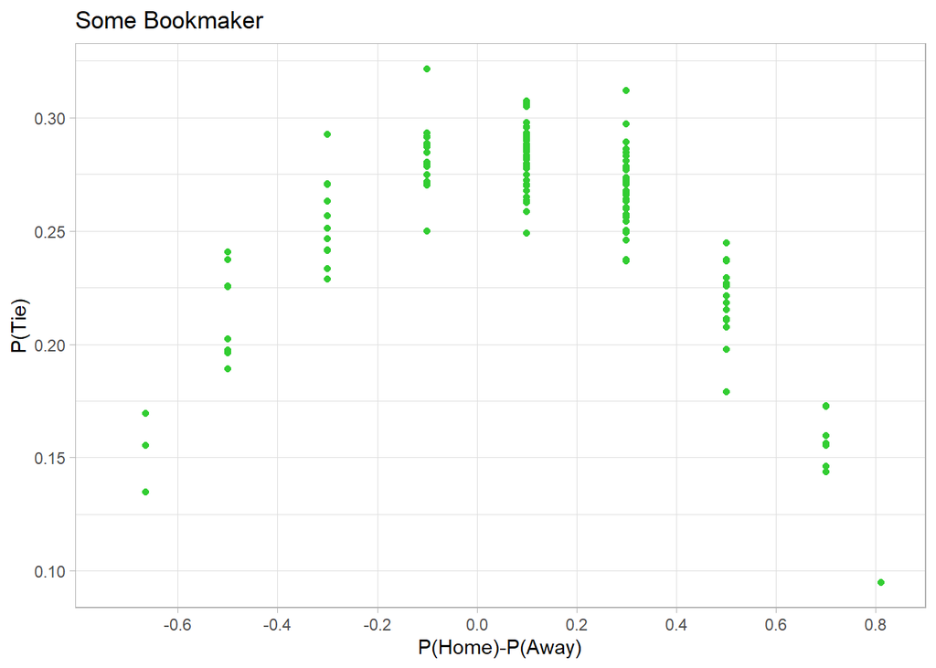

```r
IW_filtered_drawplot_binned<-ggplot(data=matches_filtered%>%filter(FTR=="D"),aes(x=IW_np_diff,y=IWD_np))+
  geom_point(color="lime green")+
  labs(x="P(Home)-P(Away)",
       y="P(Tie)",
       title="Some Bookmaker",
       color="Full Time Result")+
  scale_x_binned(breaks = seq(-1, 1, by = 0.2))+
  theme_light()
IW_filtered_drawplot_binned
```

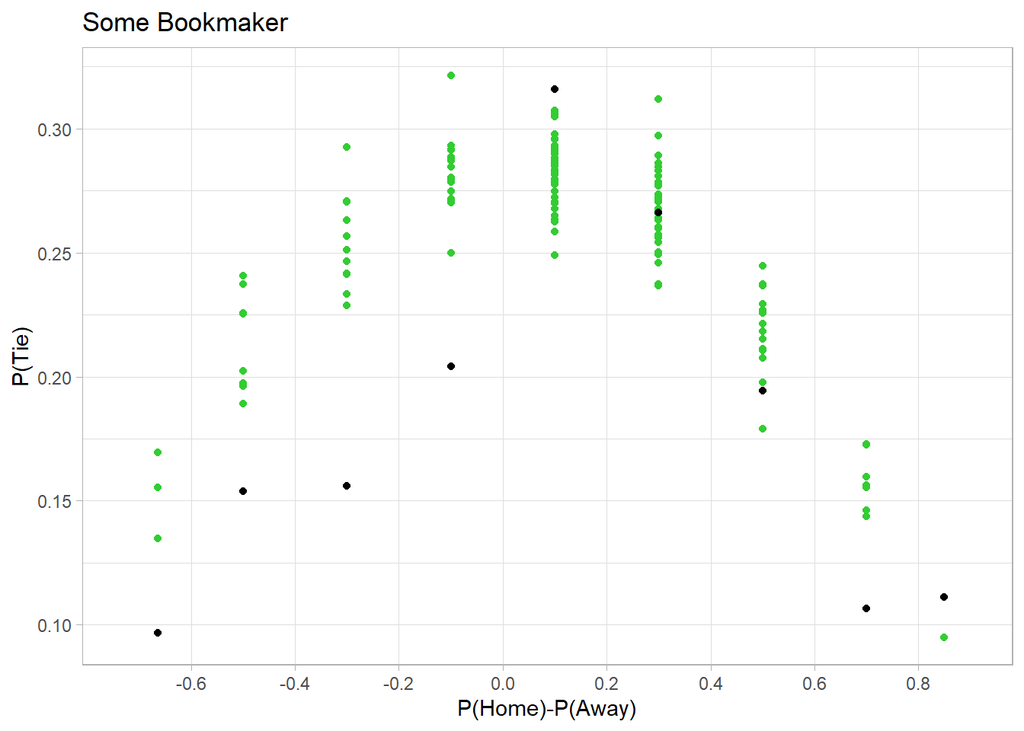

```r
IW_bins<-matches_filtered%>%mutate(bin_IW=ifelse(IW_np_diff>=-1 & IW_np_diff<=-0.8,-0.9,
                                        ifelse(IW_np_diff>-0.8 & IW_np_diff<=-0.6,-0.7,
                                               ifelse(IW_np_diff>-0.6 & IW_np_diff<=-0.4,-0.5,
                                                      ifelse(IW_np_diff>-0.4 & IW_np_diff<=-0.2,-0.3,
                                                             ifelse(IW_np_diff>-0.2 & IW_np_diff<=0,-0.1,
                                                                    ifelse(IW_np_diff>0 & IW_np_diff<=0.2,0.1,
                                                                           ifelse(IW_np_diff>0.2 & IW_np_diff<=0.4,0.3,
                                                                                  ifelse(IW_np_diff>0.4 & IW_np_diff<=0.6,0.5,
                                                                                         ifelse(IW_np_diff>0.6 & IW_np_diff<=0.8,0.7,
                                                                                                0.9))))))))))%>%
  group_by(bin_IW)


IW_estimated<-full_join(IW_bins%>%summarise(total=n()),IW_bins%>%filter(FTR=="D")%>%summarise(draw=n()))
IW_estimated[is.na(IW_estimated)] <- 0
IW_estimated<-IW_estimated%>%mutate(EstimatedProbability=draw/total)

IW_filtered_drawplot_binned+
  geom_point(data=IW_estimated,aes(x=bin_IW,y=EstimatedProbability))
```

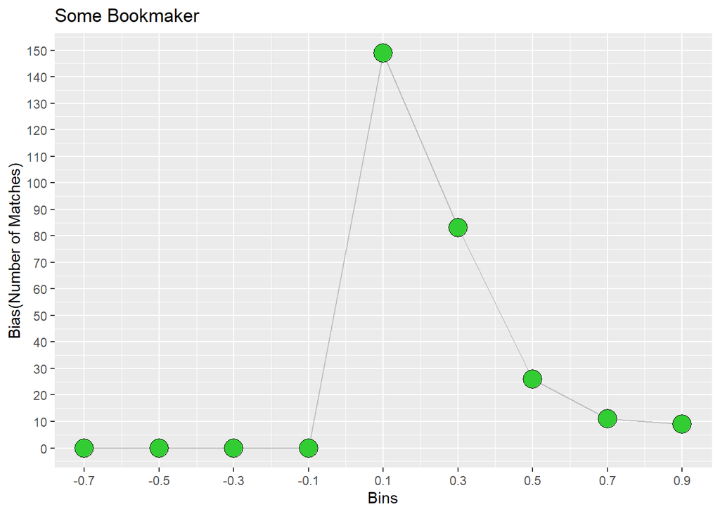

```r
bias_IW<-merge(x =IW_bins[ , c("IWD_np", "bin_IW")],y = IW_estimated[ , c("EstimatedProbability", "bin_IW")], by = "bin_IW", all.x=TRUE)

bias_IW<-bias_IW%>%mutate(is_bias=ifelse(EstimatedProbability-IWD_np>0,1,0))%>%group_by(bin_IW)%>%summarise(bias=sum(is_bias))

ggplot(data=bias_IW,aes(x=bin_IW,y=bias))+
  geom_line(color="grey")+
  geom_point(shape=21,color="black",fill="lime green",size=6)+
  scale_x_continuous(breaks=seq(from=-0.9,to=0.9,by=0.2))+
  scale_y_continuous(breaks=seq(from=0,to=200,by=10))+
  labs(title="Some Bookmaker",
       y="Bias(Number of Matches)",
       x="Bins")
```

*Total Bias for Some Bookmaker*

```r
bias_IW%>%summarise(total_bias=sum(bias))
```

```
## # A tibble: 1 x 1
##   total_bias
##        <dbl>
## 1        278
```

**Pinnacle**

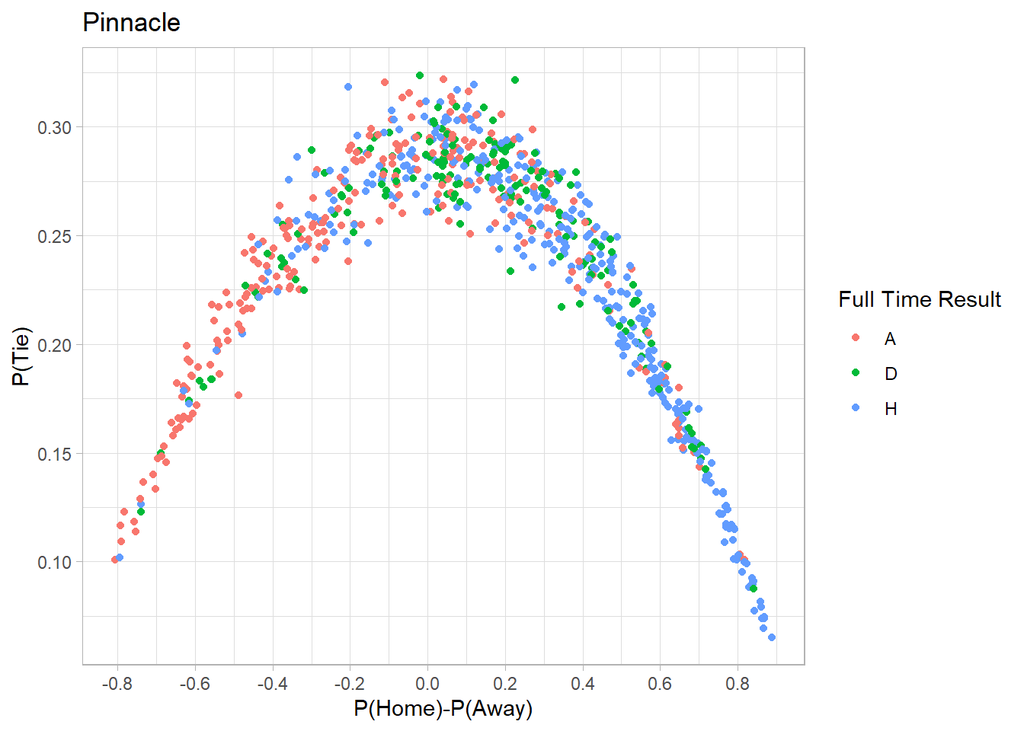

```r
PS_filtered_drawplot<-ggplot(data=matches_filtered,aes(x=PS_np_diff,y=PSD_np))+
  geom_point(aes(color=FTR))+
  labs(x="P(Home)-P(Away)",
       y="P(Tie)",
       title="Pinnacle",
       color="Full Time Result")+
  scale_x_continuous(breaks = seq(-1, 1, by = 0.2))+
  theme_light()
PS_filtered_drawplot
```

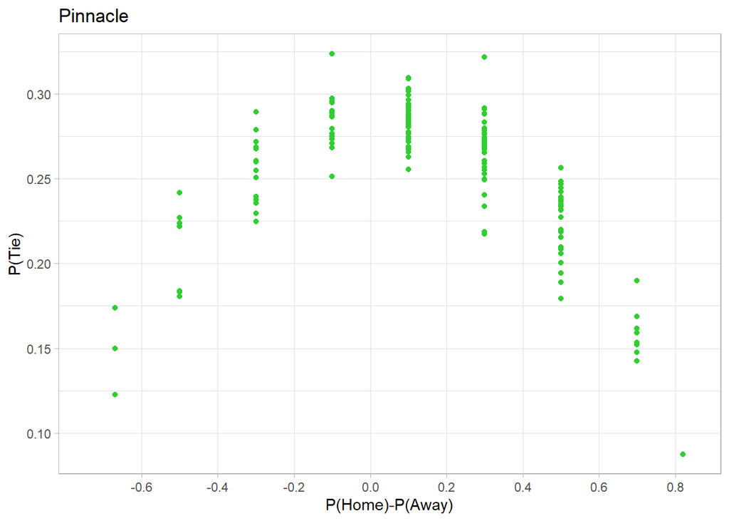

```r
PS_filtered_drawplot_binned<-ggplot(data=matches_filtered%>%filter(FTR=="D"),aes(x=PS_np_diff,y=PSD_np))+
  geom_point(color="lime green")+
  labs(x="P(Home)-P(Away)",
       y="P(Tie)",
       title="Pinnacle",
       color="Full Time Result")+
  scale_x_binned(breaks = seq(-1, 1, by = 0.2))+
  theme_light()
PS_filtered_drawplot_binned
```

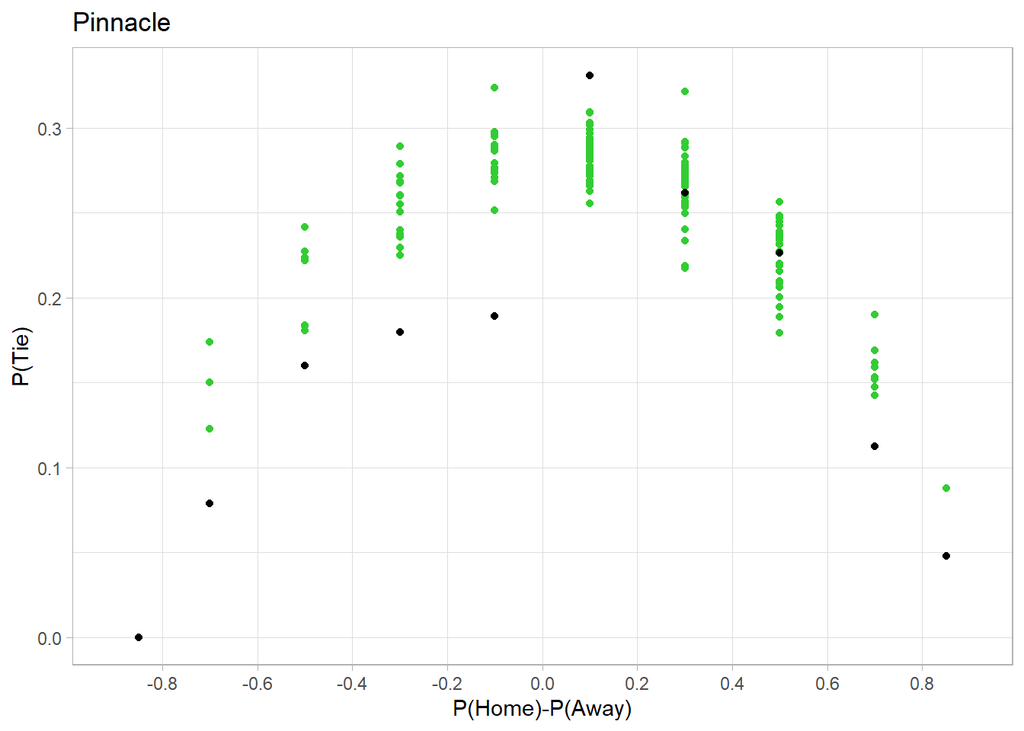

```r
PS_bins<-matches_filtered%>%mutate(bin_PS=ifelse(PS_np_diff>=-1 & PS_np_diff<=-0.8,-0.9,
                                        ifelse(PS_np_diff>-0.8 & PS_np_diff<=-0.6,-0.7,
                                               ifelse(PS_np_diff>-0.6 & PS_np_diff<=-0.4,-0.5,
                                                      ifelse(PS_np_diff>-0.4 & PS_np_diff<=-0.2,-0.3,
                                                             ifelse(PS_np_diff>-0.2 & PS_np_diff<=0,-0.1,
                                                                    ifelse(PS_np_diff>0 & PS_np_diff<=0.2,0.1,
                                                                           ifelse(PS_np_diff>0.2 & PS_np_diff<=0.4,0.3,
                                                                                  ifelse(PS_np_diff>0.4 & PS_np_diff<=0.6,0.5,
                                                                                         ifelse(PS_np_diff>0.6 & PS_np_diff<=0.8,0.7,
                                                                                                0.9))))))))))%>%
  group_by(bin_PS)


PS_estimated<-full_join(PS_bins%>%summarise(total=n()),PS_bins%>%filter(FTR=="D")%>%summarise(draw=n()))
PS_estimated[is.na(PS_estimated)] <- 0
PS_estimated<-PS_estimated%>%mutate(EstimatedProbability=draw/total)

PS_filtered_drawplot_binned+
  geom_point(data=PS_estimated,aes(x=bin_PS,y=EstimatedProbability))
```

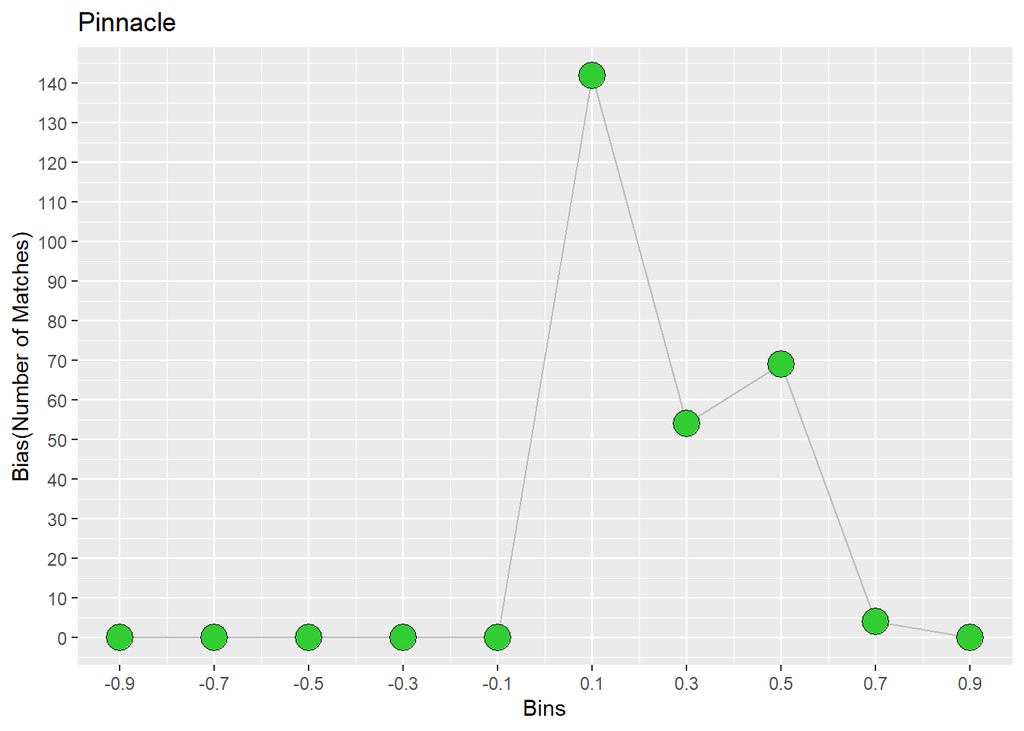

```r
bias_PS<-merge(x = PS_bins[ , c("PSD_np", "bin_PS")],y = PS_estimated[ , c("EstimatedProbability", "bin_PS")], by = "bin_PS", all.x=TRUE)

bias_PS<-bias_PS%>%mutate(is_bias=ifelse(EstimatedProbability-PSD_np>0,1,0))%>%group_by(bin_PS)%>%summarise(bias=sum(is_bias))

ggplot(data=bias_PS,aes(x=bin_PS,y=bias))+
  geom_line(color="grey")+
  geom_point(shape=21,color="black",fill="lime green",size=6)+
  scale_x_continuous(breaks=seq(from=-0.9,to=0.9,by=0.2))+
  scale_y_continuous(breaks=seq(from=0,to=200,by=10))+
  labs(title="Pinnacle",
       y="Bias(Number of Matches)",
       x="Bins")
```

*Total Bias for Pinnacle*

```r
bias_PS%>%summarise(total_bias=sum(bias))
```

```
## # A tibble: 1 x 1
##   total_bias
##        <dbl>
## 1        269
```

## 4.2 Comments about the Analysis

*Bet365*

Bins that have the highest biases : 6th and 7th  
Total bias : 286  
Ratio (Total Bias/Total Number of Matches) : 0.39

*BetAndWin*

Bins that have the highest biases : 5th and 6th  
Total bias : 289  
Ratio (Total Bias/Total Number of Matches) : 0.39

*Some Bookmaker*

Bins that have the highest biases : 5th and 6th  
Total bias : 278  
Ratio (Total Bias/Total Number of Matches) : 0.38

*Pinnacle*

Bins that have the highest biases : 6th and 8th  
Total bias : 269  
Ratio (Total Bias/Total Number of Matches) : 0.36

From the results, the number of matches whose odds are not well proposed is high again in 6th range for all bookmakers. The number is also high in 7th, 5th and 8th bins similarly.  
In addition, the bias ratios of Bet365 and BetAndWin are the highest ones.  
The most interesting result can be that all the bias ratios increase when the matches in which red cards are showed are eliminated. That is, if there is no red card in a match, bias ratios increase and it is more possible to make money in the long run.